# R Notebook

# Part 1: Theory - Introductory R Hands-On Workshop

1. **First**: Create a new script: File -> New file -> R Script
2. Get familiar with RStudio GUI

**Basic Operators**: * assignment operators: (<-, =) * separation operators: (;,) –> (‘;’ separates statements while ‘,’ separates arguments) eg. read.csv(file = ‘test.csv’ ,sep = ’’); View(test.csv) * algebraic operators: (+,-,*,/) are used for mathematical operations eg. 5+7* TAB: Can be used to search functions and arguments eg. read.csv(TAB)

## Variables Types

**Variable Types**: * char = character (categorical variables) = read as a word eg. ‘helloworld’ * numeric = any number eg. 1 or 5.43 * int = integer = discrete value with a numerical component eg. 2L, 3L, 4L etc * bool = boolean (also known as logical) = TRUE or FALSE value * factor = discrete value (ordinal variable) eg. ‘good’, ‘better’, ‘best’

### Variables: Character & Numeric (char & num)

You create a variable by **assigning** it a value with an assignment operator (<-, =). * In R the left side is left for the assignment * (<-) Is not commutative (2 <- a not allowed ; a <- 2 != a -> 2) * (=) Commutative ( 2 = a not allowed ; a = 2)

Let’s create a variable by assigning it a numerical value!

```r
a <- 2
a
```

```
[1] 2
```

```r
a.1 = 3
a.1
```

```
[1] 3
```

Look at the Environment section to see variables you’ve made and their current values. Change the value of a, then check again at the Environment section to see the updated value.

```r
a <- 3 + 5
a
```

```
[1] 8
```

#### Assigning different values to a variable (variable types)

Let’s explore. Try this:

```r
c ; d
```

```
[1] "5"
[1] "helloworld"
```

Now try this:

```r
c.1 <- 5
c.1
```

```
[1] 5
```

Now try this: what happens?

```r
c <- c(4,3,'5',7)
c
```

[output not shown]

```r
a <- 'RStudio'      # quotation marks make character variables
a.3 <- as.character(5)  # this is another way to make the character variable type

a
a.3
```

### Variables: Boolean Data

Boolean or logical variables only have true and false options. Computers see “true” as 1 and “false” as 0. Create a logical variable (boolean value) then look at the Environment section to look at the variable type.

```r
a.5 <- TRUE
a.6 <- c(TRUE, FALSE, FALSE, TRUE)
a.5
```

```
[1] TRUE
```

```r
a.6
```

```
[1]  TRUE FALSE FALSE  TRUE
```

You can find out the data type with different native R functions: class() and str()

```r
class(a.5); str(a.6)
```

```
[1] "logical"
 logi [1:4] TRUE FALSE FALSE TRUE
```

## Data Types

**Data Types**: * factor: * vector: * matrix: * array: * data.frame: * list: * (among other eg. Date)

Note: We are focusing in this workshop on vectors and data.frames.

#### Creating Vectors

The function: **c()** creates a vector by combining values into a common type ie. a sequence of data points of the same type (?c())

```r
b <- c(1,3,5,7,9)
b
```

```
[1] 1 3 5 7 9
```

There are many functions with equal or similar outcome eg. sequence() or range()

```r
b.2 <- sequence(12)
b.2
```

```
 [1]  1  2  3  4  5  6  7  8  9 10 11 12
```

With an operator: ‘:’ = range

```r
b.1 <- 1:12
b.1
```

```
 [1]  1  2  3  4  5  6  7  8  9 10 11 12
```

There are also questions you can ask R that will give boolean answers. Ask R whether a is a numeric (non-character) variable.

```r
is.numeric(a)
```

```
[1] FALSE
```

Now try these questions:

```r
is.logical(a); is.character(a)
```

[output not shown]

### Functions

We have been using functions to ask R questions and to give it tasks. The functions we have used so far are:

```r
c()
is.character(a) # checks if variable a is a character
as.character(a) # states that variable a is a character
as.character(5) # states that value 5 is a character == '5'

is.numeric(a) # same for integers
is.logical(a) # same for boolean

is.data.frame(a) # same for data types (dataframe, vector)
is.vector(b)
```

Functions have a function name (c, as.character, is.numeric etc). The function name is followed by curved brackets:() Functions always have these brackets, even if there’s nothing inside. The area inside the brackets can be used to give the function information

```r
as.character(5)
```

```
[1] "5"
```

```r
b <- as.character(5)
```

Q1 –> What variable type would b be, and what would its value be? A:

### Data Frames

The data frame structure is used in most applications of R. The data.frame() function makes data frames out of your data. A data frame is like a table: it stores your data neatly.

```r
# Create three vectors: a, b, c.
# (Reminder: a vector is a sequence of data that has the same variable type)
a <- c(1,2,3,4,10,11,12)
b <- c(5,6,7,8,13,14,15)
c <- c('yes','no','no','yes','no','yes','yes')
```

Combine these vectors to make and store a data frame called myData (or call it something else if you want!)

|  | a | b | c |
| --- | --- | --- | --- |
| 1 | 1 | 5 | yes |
| 2 | 2 | 6 | no |
| 3 | 3 | 7 | no |

## Basic Operations

### Accessing elements in a data.frame

Data frames use the *[ROW, COLUMN]* access structure:

Example 1: To access the element in the 4th row, 2nd column of the data frame:

```r
myData[4,2]
```

```
[1] 8
```

```r
myData$a
```

```
[1]  1  2  3  4 10 11 12
```

```r
myData[,1]
```

```
[1]  1  2  3  4 10 11 12
```

|  | a | b | c |
| --- | --- | --- | --- |
| 1 | 1 | 5 | yes |

# Part 2: Exercises - Introductory R Hands-On Workshop Part1:

## Step 1: Set the working directory

You can import data into R from lots of different file types. You can also import it from any location. Today we’re going to import data from a file you have on your computer.

1. The file is called ‘diamonds.csv’, you should have downloaded it (if not, time to download now!). Lookup link for some documentation: https://www.kaggle.com/shivam2503/diamonds
2. Find out where your diamonds.csv file is: probably in your /Downloads folder.
3. Check where Rstudio looks to find new data.
4. “Working directory” is the name that Rstudio uses for the place its data is stored. To find out, enter this line (get working directory):

```r
getwd()
```

```
[1] "/Users/laurita/Documents"
```

This function asks Rstudio to tell you where the current working directory is. This is probably not set to your Downloads folder at the moment. To set it to your Downloads folder, type:

```r
setwd("~/Documents/GitHub/meetup_presentations_miami/20170823_intro_workshop/")
```

[output not shown]

Now enter this line again to check that you’re in the same location as your diamonds.csv file:

```r
getwd()
```

[output not shown]

## Step 2: Data Import and exploration

1. Load your data
2. Read data set using a function that loads csv files

```r
library(readr)
diamonds <- read_csv("~/Documents/GitHub/meetup_presentations_miami/20170823_intro_workshop/diamonds.csv")
```

To have a quick look at the first few rows of the dataset, type:

| X1 | X | carat | cut | color | clarity | depth | table | price | x | y | z |
| --- | --- | --- | --- | --- | --- | --- | --- | --- | --- | --- | --- |
| 11340 | 11340 | 1.01 | Good | F | SI1 | 63.8 | 59 | 4989 | 6.32 | 6.29 | 4.02 |
| 24740 | 24740 | 2.17 | Premium | F | SI2 | 59.3 | 61 | 13084 | 8.60 | 8.53 | 5.08 |
| 20063 | 20063 | 0.31 | Premium | F | VS2 | 60.8 | 60 | 625 | 4.34 | 4.37 | 2.65 |
| 6702 | 6702 | 0.25 | Very Good | E | VS2 | 59.7 | 61 | 409 | 4.08 | 4.10 | 2.44 |
| 50756 | 50756 | 0.70 | Ideal | H | SI2 | 61.8 | 57 | 2298 | 5.67 | 5.72 | 3.52 |
| 10539 | 10539 | 1.01 | Premium | G | SI1 | 61.0 | 58 | 4808 | 6.53 | 6.49 | 3.97 |

You can also have a quick look at the last few rows

| X1 | X | carat | cut | color | clarity | depth | table | price | x | y | z |
| --- | --- | --- | --- | --- | --- | --- | --- | --- | --- | --- | --- |
| 13754 | 13754 | 1.00 | Premium | F | VS2 | 61.9 | 59 | 5606 | 6.38 | 6.34 | 3.94 |
| 4349 | 4349 | 0.72 | Ideal | E | VS2 | 61.5 | 56 | 3601 | 5.77 | 5.81 | 3.56 |
| 9462 | 9462 | 0.90 | Very Good | G | VS2 | 62.5 | 57 | 4600 | 6.12 | 6.14 | 3.83 |
| 50317 | 50317 | 1.06 | Fair | I | I1 | 64.5 | 57 | 2239 | 6.47 | 6.33 | 4.13 |
| 34531 | 34531 | 0.33 | Ideal | G | VVS1 | 62.0 | 56 | 868 | 4.45 | 4.48 | 2.77 |
| 47965 | 47965 | 0.52 | Ideal | D | VS2 | 61.8 | 57 | 1919 | 5.20 | 5.16 | 3.20 |

To see how RStudio stores the diamonds data set, print the structure:

```r
str(diamonds)
```

```
Classes ‘tbl_df’, ‘tbl’ and 'data.frame':   1000 obs. of  12 variables:
 $ X1     : int  11340 24740 20063 6702 50756 10539 35854 17090 41117 26224 ...
 $ X      : int  11340 24740 20063 6702 50756 10539 35854 17090 41117 26224 ...
 $ carat  : num  1.01 2.17 0.31 0.25 0.7 1.01 0.32 1.2 0.44 2.18 ...
 $ cut    : chr  "Good" "Premium" "Premium" "Very Good" ...
 $ color  : chr  "F" "F" "F" "E" ...
 $ clarity: chr  "SI1" "SI2" "VS2" "VS2" ...
 $ depth  : num  63.8 59.3 60.8 59.7 61.8 61 61.7 62.5 61.6 61.2 ...
 $ table  : num  59 61 60 61 57 58 55 57 58 56 ...
 $ price  : int  4989 13084 625 409 2298 4808 917 6814 1196 15646 ...
 $ x      : num  6.32 8.6 4.34 4.08 5.67 6.53 4.39 6.81 4.85 8.39 ...
 $ y      : num  6.29 8.53 4.37 4.1 5.72 6.49 4.43 6.73 4.89 8.51 ...
 $ z      : num  4.02 5.08 2.65 2.44 3.52 3.97 2.72 4.23 3 5.17 ...
 - attr(*, "spec")=List of 2
  ..$ cols   :List of 12
  .. ..$ X1     : list()
  .. .. ..- attr(*, "class")= chr  "collector_integer" "collector"
  .. ..$ X      : list()
  .. .. ..- attr(*, "class")= chr  "collector_integer" "collector"
  .. ..$ carat  : list()
  .. .. ..- attr(*, "class")= chr  "collector_double" "collector"
  .. ..$ cut    : list()
  .. .. ..- attr(*, "class")= chr  "collector_character" "collector"
  .. ..$ color  : list()
  .. .. ..- attr(*, "class")= chr  "collector_character" "collector"
  .. ..$ clarity: list()
  .. .. ..- attr(*, "class")= chr  "collector_character" "collector"
  .. ..$ depth  : list()
  .. .. ..- attr(*, "class")= chr  "collector_double" "collector"
  .. ..$ table  : list()
  .. .. ..- attr(*, "class")= chr  "collector_double" "collector"
  .. ..$ price  : list()
  .. .. ..- attr(*, "class")= chr  "collector_integer" "collector"
  .. ..$ x      : list()
  .. .. ..- attr(*, "class")= chr  "collector_double" "collector"
  .. ..$ y      : list()
  .. .. ..- attr(*, "class")= chr  "collector_double" "collector"
  .. ..$ z      : list()
  .. .. ..- attr(*, "class")= chr  "collector_double" "collector"
  ..$ default: list()
  .. ..- attr(*, "class")= chr  "collector_guess" "collector"
  ..- attr(*, "class")= chr "col_spec"
```

Q2 –> How many variables and observations does the data contain? Q3 –> What types of variables does the data contain?

#### A Summary of Variable Types:

- numeric = any number eg. 1 or 5.43
- int = integer = discrete value with a numerical component eg. 2L, 3L, 4L etc
- bool = boolean (also known as logical) = TRUE or FALSE value
- char = character = read as a word eg ‘hello’
- factor = discrete value eg. ‘good’, ‘better’, ‘best’

Another helpful function is ‘summary’. Different handling according to variable type:

```r
summary(diamonds)
```

```
       X1              X             carat            cut               color             clarity              depth
 Min.   :   50   Min.   :   50   Min.   :0.2300   Length:1000        Length:1000        Length:1000        Min.   :53.80
 1st Qu.:13871   1st Qu.:13871   1st Qu.:0.4000   Class :character   Class :character   Class :character   1st Qu.:61.20
 Median :25850   Median :25850   Median :0.7050   Mode  :character   Mode  :character   Mode  :character   Median :61.90
 Mean   :26419   Mean   :26419   Mean   :0.8091                                                            Mean   :61.84
 3rd Qu.:39199   3rd Qu.:39199   3rd Qu.:1.0500                                                            3rd Qu.:62.60
 Max.   :53938   Max.   :53938   Max.   :4.0100                                                            Max.   :68.80
     table           price             x                y               z
 Min.   :51.00   Min.   :  367   Min.   : 3.850   Min.   :3.900   Min.   :2.350
 1st Qu.:56.00   1st Qu.:  942   1st Qu.: 4.710   1st Qu.:4.730   1st Qu.:2.900
 Median :57.00   Median : 2514   Median : 5.720   Median :5.715   Median :3.540
 Mean   :57.42   Mean   : 4072   Mean   : 5.745   Mean   :5.749   Mean   :3.554
 3rd Qu.:59.00   3rd Qu.: 5835   3rd Qu.: 6.540   3rd Qu.:6.540   3rd Qu.:4.050
 Max.   :79.00   Max.   :18741   Max.   :10.020   Max.   :9.940   Max.   :6.240
```

## Step 3: Visualize your data

R is really useful because of its packages

*What’s a package?* A package is some code that someone else has taken the time to perfect. Each package is usually useful for one particular application. For example, there is a package called ‘dplyr’ that is useful for data sorting and filtering

(…Continue with the exercise) We want to make beautiful graphs, and to be able to customise them easily. A great package for this is ggplot2.

### Installing & Loading packages

```r
install.packages("ggplot2")
install.packages("ggplot2")
library(ggplot2)
```

#### Data Visualization with ggplot(): Scatterplot

The package ggplot2 includes a function called ggplot(). We use the ggplot() function to create graphs using our data. Let’s see how diamond price changes due to carat.

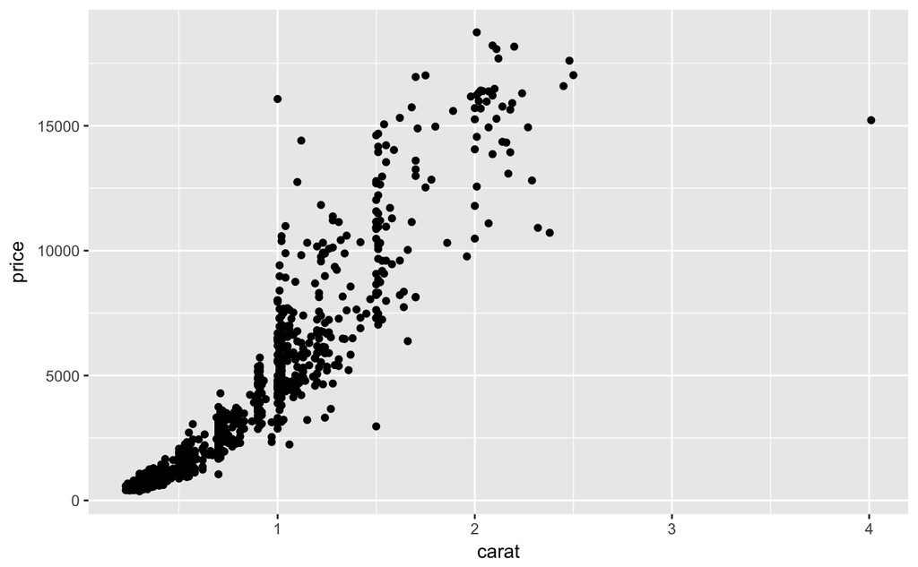

Let’s deconstruct this command: * ggplot – function that creates the basic ggplot graph * data - the data frame that you want to use * aes – short for aesthetic, describes how your variables are graphed * geom – the functions that tell ggplot how you want the data presented (scatter plot, histogram etc)

Lets add some colors according to the cut

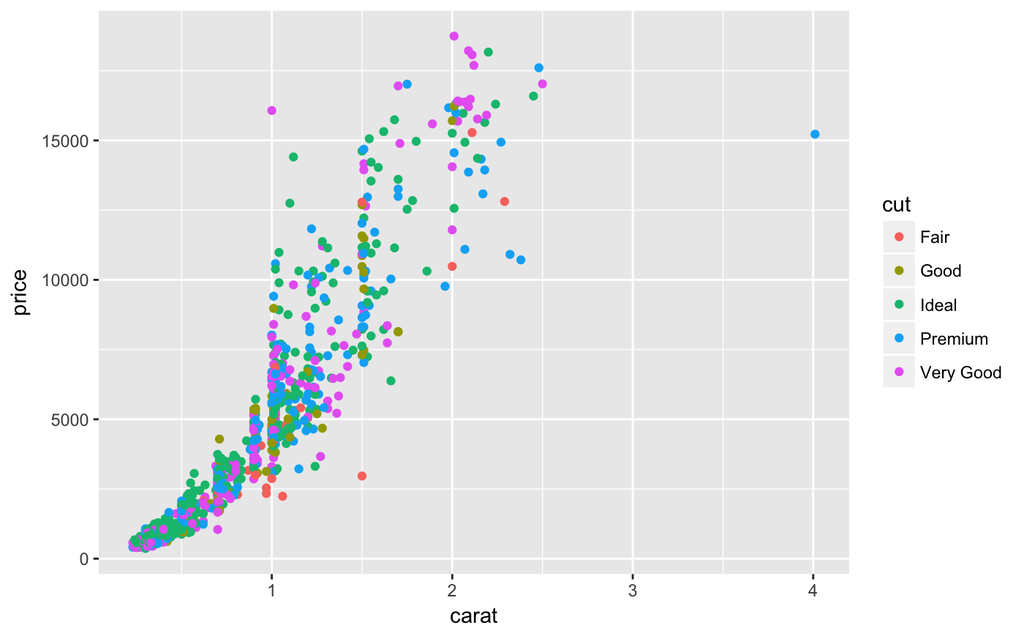

Let’s make it more readable:

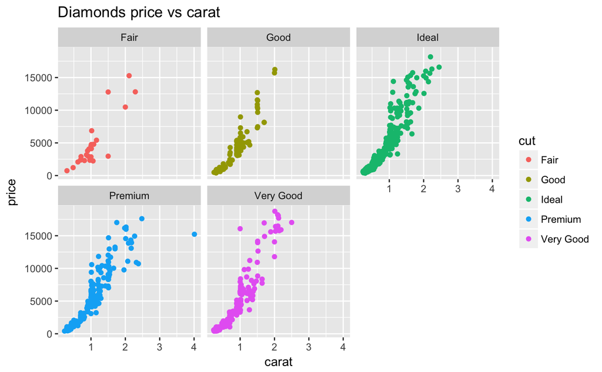

#### Data Visualization with ggplot(): Histogram

Lets explore the price range of diamonds

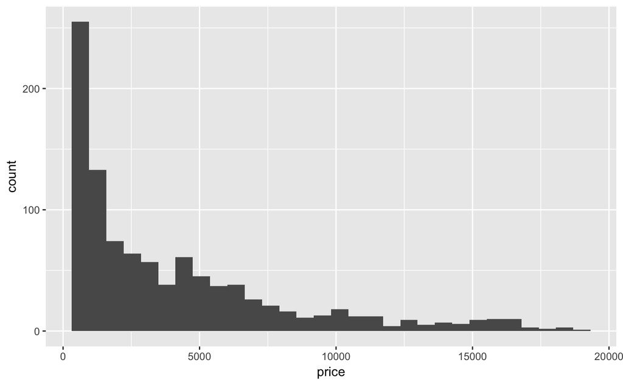

Let’s make it better!

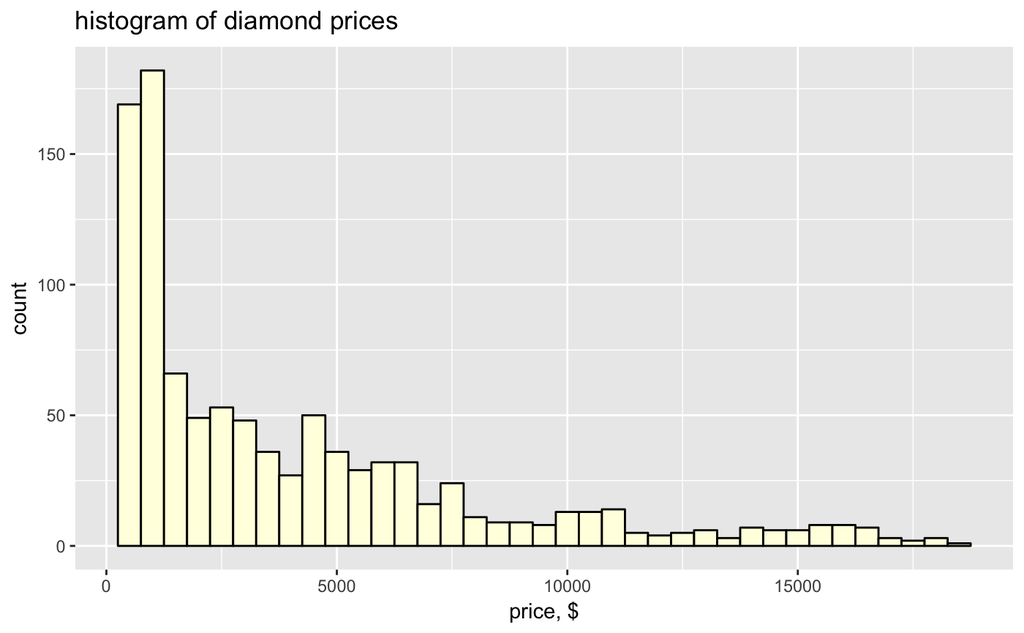

*Try by yourself:* 1. Experiment with the binwidth value. 2. Use scale_x_continuous() to see what happens:

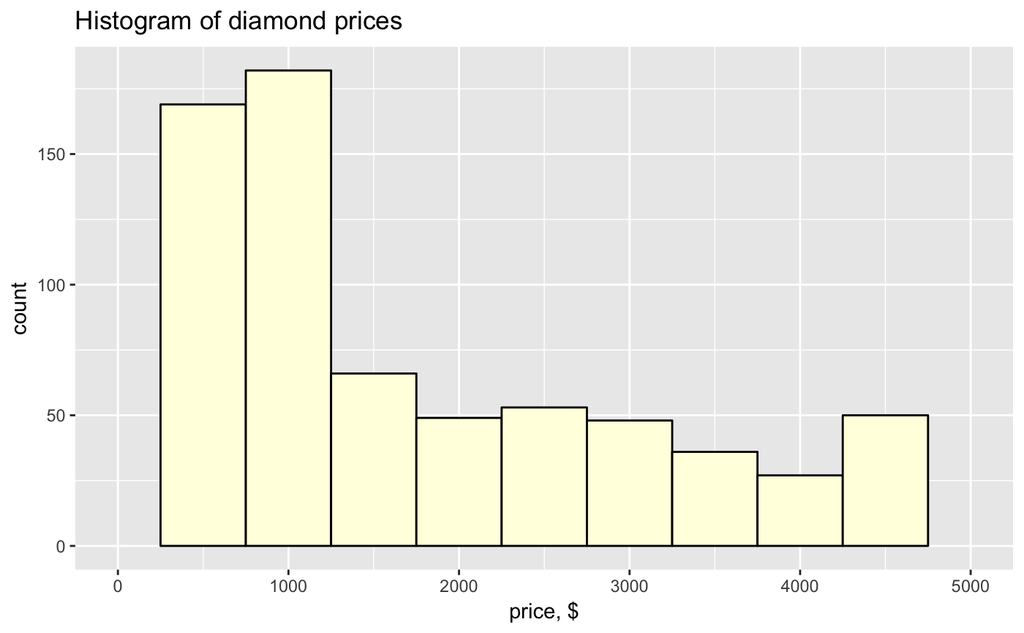

Q5 –> What does this histogram tell you?

#### Data Visualization with ggplot(): Boxplot

Let’s explore some boxplots:

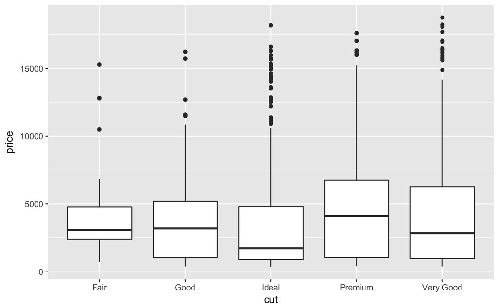

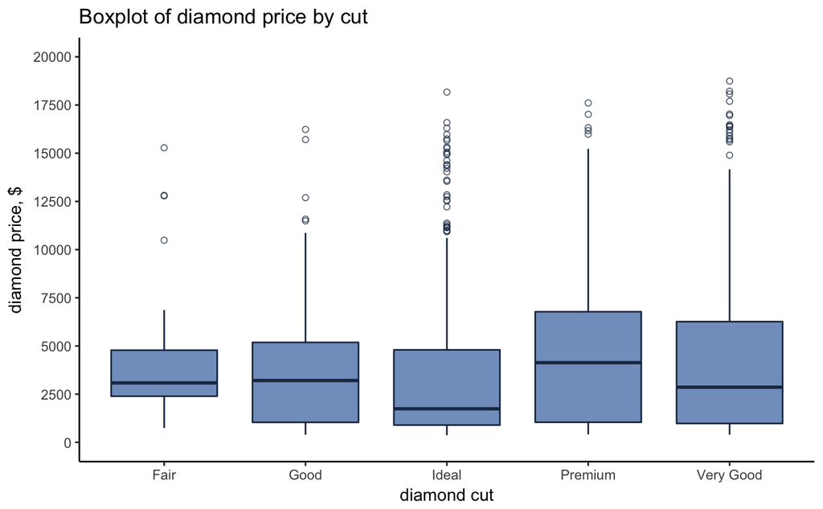

## Resources & References:

- Stack Overflow: https://stackoverflow.com/documentation/r/topics
- Free Udacity ‘Data Analysis with R’ course: https://www.udacity.com/course/data-analysis-with-r--ud651
- Free Coursera ‘R Programming’ course: https://www.coursera.org/learn/r-programming
- R for Data Science by G.Grolemund and H. Wickham: http://r4ds.had.co.nz/index.html

## RStudio Help

Use R internal help systems by typing directly into the window: ?read.csv() ?mean() help()